# Assignment 2

#### Complete the code cells in this Jupyter notebook, and submit the final .ipynb notebook to Gradescope

##### Make sure you save your changes in VS Code before uploading it (beware of the little "dot" in the tab above)

##### You should **execute all code cells** before saving and submitting. We need to see the outputs/figures generated by Python

(a) Import the pandas and matplotlib packages

```python
# Write your answer

import pandas as pd
import matplotlib.pyplot as plt
```

(b) Open the dataset "united_states_co2_emissions.csv" in the "data" folder using pandas

- Assign it to a variable named "us_emissions"
- Note: This contains CO2 emissions (in kilotons) by the United States from 1960-2019.  
  It is compiled from various sources, including the United Nations Framework Convention  
  on Climate Change (UNFCCC) and the International Energy Agency (IEA).

```python
# Write your answer
us_emissions = pd.read_csv('data/united_states_co2_emissions.csv')
print(type(us_emissions))
```

```
<class 'pandas.core.frame.DataFrame'>
```

(c) View the dataset and create a list of variable names

- The us_emissions dataset has two named column headings.
- Create a list containing two strings, one for each of the column headings.
- The strings must match the headings **exactly** (the "#" symbols shown in DataWrangler are not part of the name). Otherwise you will run into a problem in part d)
- Assign this list to a variable called "columns"
- You do not have to "extract" the names from the dataset through a Python command. You can simply type them manually.

```python
# Write your answer
year = "Year"
total_emissions = "Total Emissions"
print(type(year))
print(type(total_emissions))
columns = year + total_emissions
print(type(columns))
```

```
<class 'str'>
<class 'str'>
<class 'str'>
```

(d) Compute descriptive statistics for the 2nd variable in the dataset

- The direct way to do this is to execute the command:

  ```
  us_emissions["total_emissions"].describe()
  ```

- Do something similar in the code cell below, but typing the string "total_emissions" is **not allowed**
- Instead of typing "total_emissions" manually, use the variable "columns" you created in the previous cell, extracting the list's 2nd element
- **Remember:** The numbering in Python starts at zero
- For example, if

  list_colors = ["red","green","yellow"],

  then list_colors[2] will be "yellow"

```python
# Write your answer
columns_list = ["year", "total_emissions"]
columns_emissions = columns_list[1]
print(columns_emissions)
us_emissions[columns_emissions].describe()
```

```
total_emissions
```

```
count    6.000000e+01
mean     4.733944e+06
std      7.568200e+05
min      2.880506e+06
25%      4.457976e+06
50%      4.862075e+06
75%      5.160723e+06
max      5.775810e+06
Name: total_emissions, dtype: float64
```

#### **Hint:** If you did everything correctly above, that cell should have the same output as the one below

```python
# run this cell to compare with your answer
us_emissions["total_emissions"].describe()
```

```
count    6.000000e+01
mean     4.733944e+06
std      7.568200e+05
min      2.880506e+06
25%      4.457976e+06
50%      4.862075e+06
75%      5.160723e+06
max      5.775810e+06
Name: total_emissions, dtype: float64
```

(e) Choose any 2 of the other countries in the "data" folder and import the  
2 datasets as you did in part (b). Create 2 **scatter plots** that have "year"  
on the x-axis (horizontal axis) and "total_emissions" in the y-axis.

- The "data" folder contains the datasets for the top 10 CO2 emitting countries
- For **full points**, label the axes in each plot.
- Use "plt.title("Relevant Title for Plot")" to create a title for the plot (substituting a more appropriate string, of course)
- Use "plt.show()" after creating each plot to ensure both are displayed
- Note: This question does not depend on (d)

```
<class 'pandas.core.frame.DataFrame'>
```

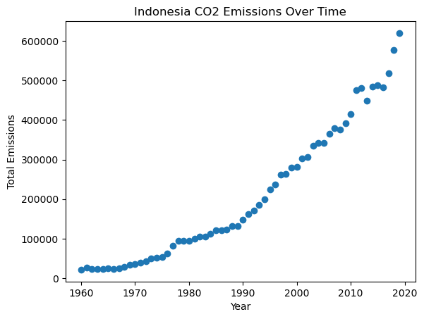

```
<class 'pandas.core.frame.DataFrame'>
```

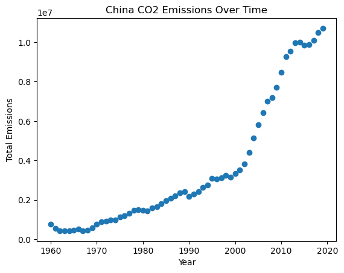

```python
# Write your answer
indonesia_emissions = pd.read_csv('data/indonesia_co2_emissions.csv')
print(type(indonesia_emissions))
indonesia_emissions
table = pd.crosstab(index = indonesia_emissions['year'], columns = indonesia_emissions['total_emissions'])
table
indonesia_emissions.describe()
plt.scatter(x = indonesia_emissions['year'], y = indonesia_emissions['total_emissions'])
plt.title("Indonesia CO2 Emissions Over Time")
plt.xlabel(year)
plt.ylabel(total_emissions)
plt.show()

china_emissions = pd.read_csv('data/china_co2_emissions.csv')
print(type(china_emissions))
china_emissions
table = pd.crosstab(index = china_emissions['year'], columns = china_emissions['total_emissions'])
table
china_emissions.describe()
plt.scatter(x = china_emissions['year'], y = china_emissions['total_emissions'])
plt.title("China CO2 Emissions Over Time")
plt.xlabel(year)
plt.ylabel(total_emissions)
plt.show()
```